# Interactive Data Visualization

Zeng Fung Liew

12/15/2020

## Preliminary code given by Prof. Duncan Temple Lang

The code given by the professor is slightly edited to fit the needs of a Windows laptop.

```r
library(httr)
library(XML)
# We manually found the following link via the Web browser's Developer Tools in the Network tab.
# We found the json files

u = "https://static01.nyt.com/newsgraphics/2020/03/16/coronavirus-maps/a3c88fc852744c0bdb9ff9ee092cc5db785705d6/data/timeseries/en/USA.json"

tt = GET(u, verbose = TRUE)
tt = rawToChar(tt$content)

library(RJSONIO)
us = fromJSON(tt)


# The URL for the JSON changes each day. So today's URL, we want to find it in the current day's page.
# We get the top-level page

ny = htmlParse(GET("https://www.nytimes.com/interactive/2020/us/coronavirus-us-cases.html?action=click&module=Top%20Stories&pgtype=Homepage"))

# Then we find the HTML elements that have an immediate child text node that contains the string USA.json.
js = xpathSApply(ny, "//*[contains(./text(), 'USA.json')]", xmlValue)

#These are <script> elements containing JavaScript, not JSON.
# But we can find the URL with a regular expression in these
u = gsub('.*"(https://[^"]+USA.json)".*', "\\1", js)
u = unique(u)
# There is only 1 URL repeated multiple times.

# So now we have these

tt = GET(u, verbose = TRUE, followlocation = TRUE)
tt = rawToChar(tt$content)
library(RJSONIO)
us = fromJSON(tt)
length(us$data)

save(us, file = "covid.RData") # data is saved in the form of RData to avoid unnecessary web scraping
```

## Interactive Trend Plot

A line plot consisting of all the trends from each county is plotted using `ggplot`. Note that in the process of building this `ggplot` object, I have added the `highlight_key` function from the `plotly` library for the purpose of interactive highlighting later on. The code used to create the `ggplot` object is shown below:

```r
library(ggplot2)
library(plotly)
library(dplyr)
trendPlot = covidDataCal %>%
  highlight_key(~County) %>%
  ggplot(aes(x = Date, y = DailyCases, color = County, group = 1,
             text = paste("County: ", FullName,
                          "\nDate: ", Date,
                          "\nDaily Cases: ", DailyCases,
                          "\nCum. Cases: ", CumCases,
                          "\nDaily Deaths: ", DailyDeaths,
                          "\nCum. Deaths: ", CumDeaths,
                          "\n% Cases/Capita (Day): ", round(PercentCasesPerCapita, 4),
                          "\n% Deaths/Capita (Day):", round(PercentDeathsPerCapita, 4),sep = ""))) +
  geom_line() +
  ggtitle("Covid-19 Cases in California by County") + ylab("Daily Cases")
trendPlot
```

After creating the `ggplot` object, the next step is to transform it into an interactive plot using `plotly`. Note that there were a few additional functions and parameters that I added to allow for higlighting and producing tooltips in the plot. Specifically, those function/parameters are:

- `tooltip = "text"` in `ggplotly()`: This parameter is used to add the text specified in the `ggplot` object created from the previous code snippet.
- `highlight()`: Highlights specific lines on hover by setting `on = "plotly_hover"`. Undo highlights and returns to default by setting `off = "plotly_doubleclick"`. An additional parameter `persistent = getOption("persistent", TRUE)` is set to allow for multiple highlighting.
- `layout(updatemenus = list())`: Used to create buttons to toggle lines in the plot. The buttons created are “Hide all” and “Show all”.

```r
# make plotly
trendPlot.plotly = ggplotly(trendPlot, tooltip = "text", dynamicTicks = TRUE) %>%
  highlight(on = "plotly_hover", off = "plotly_doubleclick",
            persistent = getOption("persistent", TRUE)) %>%
  layout(updatemenus = list(
    list(type = "buttons",
         direction = "right",
         xanchor = "left",
         yanchor = "top",
         showactive = FALSE,
         x = 1,
         y = 1.2,
         buttons = list(
           list(method = "restyle",
                args = list("visible", "all"),
                label = "show all"),
           list(method = "restyle",
                args = list("visible", "legendonly"),
                label = "hide all")
         )
    )
  ))
trendPlot.plotly$sizingPolicy$browser$fill = FALSE
trendPlot.plotly
```

The resulting HTML ouput can be viewed in “covidTrend.html”.

## Plotting map using `ggplot`

The following code is used to build the `ggplot` map that will subsequently be used to create the non-interactive COVID-19 map gif, and the interactive COVID-19 plotly map.

Some explanations:

- `map_data` function from the `maps` library is used to obtained the longitude and latitude data of each counties in California. This is then joined with the `covidDataCal` data frame from a previous snippet.
- Cumulative cases is not able to tell the viewer much about the COVID-19 cases in each county due to the extreme outlier which is Los Angeles. Hence, the number of cases per 10,000 people is displayed instead.
- An important parameter in this `ggplot` is the `frame = Date` parameter as it helps us navigate the number of cases for each day in the interactive plot and gif later on.

```r
library(maps)
# join covidDataCal with mapCounty
calCountyMap = map_data('county', 'california')
calCountyMap$subregion = stringr::str_to_title(calCountyMap$subregion)
plotData = inner_join(calCountyMap, covidDataCal, by = c("subregion" = "County"))

# make the ggplot
options(scipen = 10)
plotData$Date = as.factor(plotData$Date)
plotData$casesPer10k = plotData$CumCases/plotData$Population*10000
covidMap = ggplot(data = plotData, aes(frame = Date,
                                      text = paste("County: ", FullName,
                                                "\nDate: ", Date,
                                                "\nCase/10k Pop.: ", casesPer10k,
                                                "\nDaily Cases: ", DailyCases,
                                                "\nCum. Cases: ", CumCases,
                                                "\nDaily Deaths: ", DailyDeaths,
                                                "\nCum. Deaths: ", CumDeaths,
                                                "\n% Cases/Capita (Day): ", round(PercentCasesPerCapita, 4),
                                                "\n% Deaths/Capita (Day):", round(PercentDeathsPerCapita, 4),sep = ""))) +
  geom_polygon(aes(x=long, y = lat, fill=casesPer10k, group = group), color="black") +
  geom_text(aes(y=40, x=-116, label=as.Date(Date)), check_overlap = TRUE, size=4, fontface="bold") +
  lims(x = c(-125, -114), y = c(32,42.5)) +
  scale_fill_gradientn(colors = rev(heat.colors(10)), na.value="grey80") +
  labs(title="Rate of COVID-19 Cases", x = "longitude", y = "latitude", fill = "Cases Per 10k Pop.")
```

### Non-interactive COVID-19 Map gif

The gif is created using the `gganimate` and `gifski`.

- `transition_manual` is used to create the color transitions ofthe cases per 10,000 people in the gif.
- `animate` is used to produce the gif animation. The `duration` and `fps` parameters are set to denote the length of the gif and speed of date transitions. The `gifski_renderer()` is required for later versions of `gganimate`, according to some StackOverflow results.

```r
# gif of covid map
library(gganimate)
library(gifski)
animatedMap <- covidMap +
  transition_manual(Date)
# get plot in GIF
mapGIF = animate(animatedMap, duration = 10, fps = 30, width = 500, height = 500, renderer = gifski_renderer())
# display gif
mapGIF
# save gif
anim_save("covidCal.gif", animation=mapGIF)
```

The resulting gif is shown below.

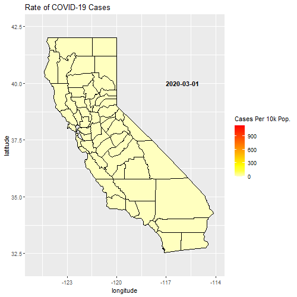

### Interactive COVID-19 Map

The code used to created the interactive COVID-19 map using `plotly` might seem very simple and straightforward below, and that is due to all the required settings have already been computed in the process of building the `ggplot` map.

I had initially tried creating the `plotly` object by adding functions and parameters using the `layout()` and `add_trace()` functions, which did work in certain ways, but somehow produced bugs in certain other areas. This was fixed by using the `frame = Date` parameter in creating the `ggplot` map instead of dealing with the `plotly` functions here, as mentioned in a previous section.

```r
# make interactive plot using plotly
covidMap.plotly = ggplotly(covidMap, tooltip = "text") %>% partial_bundle()
covidMap.plotly
saveWidget(covidMap.plotly, "covidMap.html", selfcontained = FALSE, title = "Covid-19 Cases by California Counties")
```

The result is the attached file “covidMap.html”.

Disclaimer: This HTML file can take a long time to load due to its large file size.

## Resources used:

- Interactive map: https://github.com/lrjager/maryland-poison-center-graphics/blob/master/mpc-map-FINAL.Rmd
- `gganimate` resource: https://towardsdatascience.com/animating-your-data-visualizations-like-a-boss-using-r-f94ae20843e3
- `gganimate` resource: https://www.5haw.com/posts/week-3-making-an-animated-map-using-maps-ggplot2-and-gganimate/
- Making plotly sliders: https://plotly.com/r/sliders/